# Korea Zinc: 주가 수준에서 확인한 시계열 구조와 단기 기준선

# 1 분석 질문

2024년 고려아연 종가의 시계열 구조를 확인하고, 가격 수준 ARIMA(0,1,0)이 제공하는 5거래일 예측을 제한적인 기준선으로 평가한다.

# 2 데이터와 인덱스 선택

자료는 KRX Data Marketplace의 고려아연(010130, KOSPI) 일별 종가다. KRX 이용약관 때문에 원자료는 저장소에 포함하지 않는다. 아래 상대경로에 사용자가 직접 내려받은 두 파일이 있어야 한다.

```r
train_path <- "../../data/raw/korea-zinc-2024.csv"
test_path  <- "../../data/raw/korea-zinc-2025-first-5.csv"

if (!all(file.exists(c(train_path, test_path)))) {
  stop("KRX CSV가 없습니다. data/README.md의 획득·배치 안내를 확인하세요.")
}

read_krx_close <- function(path) {
  # 원본 첫 행의 CP949 한글 열 이름을 건너뛰고 두 열을 명시한다.
  x <- read.csv(path, skip = 1, header = FALSE,
                col.names = c("date", "price"))
  x <- x[complete.cases(x), ]
  x$date <- as.Date(x$date)
  x <- x[order(x$date), ]
  rownames(x) <- NULL
  x
}

train <- read_krx_close(train_path)
actual <- head(read_krx_close(test_path), 5)
stopifnot(nrow(train) == 244, nrow(actual) == 5)

knitr::kable(rbind(head(train, 3), tail(train, 3)),
             caption = "2024년 거래일 종가의 시작과 끝")
```

2024년 거래일 종가의 시작과 끝

|  | date | price |
| --- | --- | --- |
| 1 | 2024-01-02 | 486000 |
| 2 | 2024-01-03 | 477000 |
| 3 | 2024-01-04 | 484500 |
| 242 | 2024-12-26 | 1219000 |
| 243 | 2024-12-27 | 1027000 |
| 244 | 2024-12-30 | 1006000 |

초기 분석의 한 버전은 휴장일을 전일 가격으로 채우고 `frequency = 365`인 시계열을 만들었다. 동일 가격의 반복은 인위적 자기상관을 만들 수 있으므로 여기서는 실제 **거래일 순서**를 인덱스로 사용한다. 달력 간격의 차이는 반영하지 못하지만 휴일 가격을 만들어 넣지는 않는다.

# 3 시계열 구조

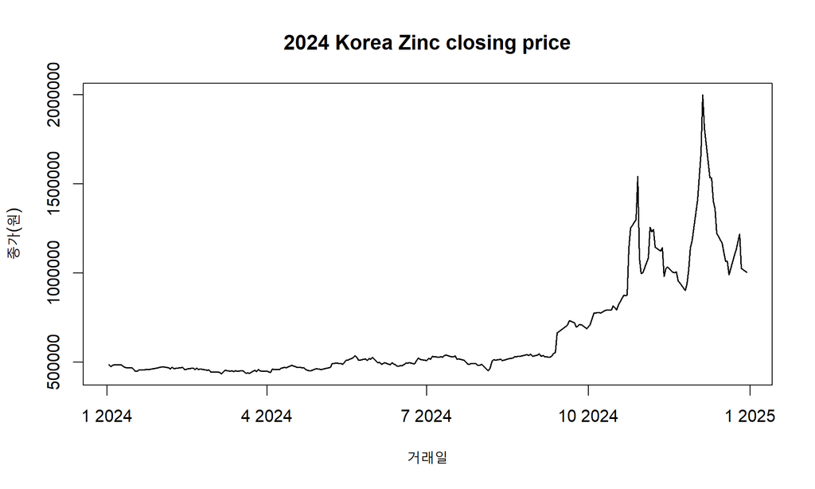

```r
plot(train$date, train$price, type = "l", lwd = 1.2,
     xlab = "거래일", ylab = "종가(원)",
     main = "2024 Korea Zinc closing price")
```

가격 수준은 일정한 평균 주위를 오가기보다 하반기, 특히 4분기에 수준과 변동폭이 크게 달라진다. 가격 수준 ARIMA는 금융자료의 이상적 분석이라기보다 비정상성과 차분의 역할을 보여주는 교육 목적 분석이다.

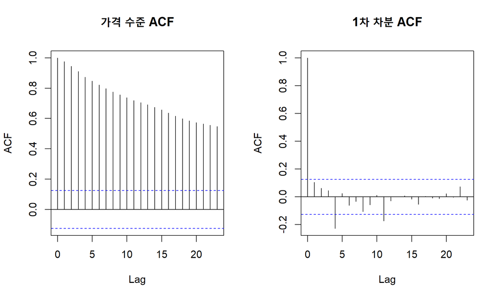

```r
price <- train$price
dprice <- diff(price)
par(mfrow = c(1, 2))
acf(price, main = "가격 수준 ACF")
acf(dprice, main = "1차 차분 ACF")
```

```r
par(mfrow = c(1, 1))
```

# 4 ARIMA 기준모형과 잔차 진단

```r
fit <- arima(price, order = c(0, 1, 0),
             include.mean = FALSE, method = "ML")

lags <- c(6, 12, 18, 24)
diagnostics <- data.frame(
  lag = lags,
  p_value = vapply(
    lags,
    function(k) Box.test(residuals(fit), lag = k,
                         type = "Ljung-Box")$p.value,
    numeric(1)
  )
)
knitr::kable(diagnostics, digits = 4,
             caption = "ARIMA(0,1,0) 잔차 Ljung–Box 검정")
```

ARIMA(0,1,0) 잔차 Ljung–Box 검정

| lag | p_value |
| --- | --- |
| 6 | 0.0055 |
| 12 | 0.0026 |
| 18 | 0.0284 |
| 24 | 0.1070 |

lag 6, 12, 18에서 5% 수준의 잔차 자기상관이 남는다. 따라서 이 모형이 구조를 충분히 설명한다고 보기 어렵고, 이후 예측은 **baseline forecast**로만 해석한다.

# 5 5거래일 기준선 예측

```r
fc <- predict(fit, n.ahead = 5)
forecast_table <- data.frame(
  date = actual$date,
  forecast = as.numeric(fc$pred),
  lower_95 = as.numeric(fc$pred - qnorm(0.975) * fc$se),
  upper_95 = as.numeric(fc$pred + qnorm(0.975) * fc$se),
  actual = actual$price
)
forecast_table$inside_95 <- with(
  forecast_table,
  actual >= lower_95 & actual <= upper_95
)
knitr::kable(forecast_table, digits = 0,
             caption = "5거래일 기준선 예측과 실제 종가")
```

5거래일 기준선 예측과 실제 종가

| date | forecast | lower_95 | upper_95 | actual | inside_95 |
| --- | --- | --- | --- | --- | --- |
| 2025-01-02 | 1006000 | 885172 | 1126828 | 957000 | TRUE |
| 2025-01-03 | 1006000 | 835124 | 1176876 | 948000 | TRUE |
| 2025-01-06 | 1006000 | 796720 | 1215280 | 931000 | TRUE |
| 2025-01-07 | 1006000 | 764345 | 1247655 | 932000 | TRUE |
| 2025-01-08 | 1006000 | 735821 | 1276179 | 902000 | TRUE |

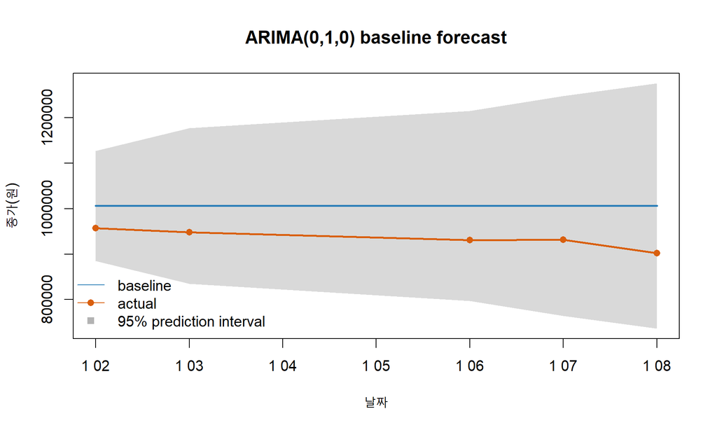

```r
ylim <- range(forecast_table[c("lower_95", "upper_95", "actual")])
plot(forecast_table$date, forecast_table$forecast, type = "l", lwd = 2,
     ylim = ylim, xlab = "날짜", ylab = "종가(원)",
     main = "ARIMA(0,1,0) baseline forecast")
polygon(c(forecast_table$date, rev(forecast_table$date)),
        c(forecast_table$lower_95, rev(forecast_table$upper_95)),
        col = adjustcolor("grey70", 0.5), border = NA)
lines(forecast_table$date, forecast_table$forecast, lwd = 2, col = "#2C7FB8")
lines(forecast_table$date, forecast_table$actual,
      lwd = 2, col = "#D95F0E", type = "o", pch = 16)
legend("bottomleft", c("baseline", "actual", "95% prediction interval"),
       col = c("#2C7FB8", "#D95F0E", "grey70"),
       lty = c(1, 1, NA), pch = c(NA, 16, 15), bty = "n")
```

다섯 실제값은 모두 95% 예측구간 안에 있다. 하지만 표본이 5개뿐이고, 구간이 시차와 함께 넓어지며, 잔차 진단도 통과하지 못했다. 이 결과는 predictive validity의 입증이 아니다.

# 6 한계

- 가격 수준보다 거래일 로그수익률을 분석하는 편이 금융 시계열에 더 자연스럽다.
- 휴일 전일값 대체와 `frequency=365`는 인위적 자기상관을 만들 수 있다.
- 변동성 변화는 ARIMA(0,1,0)으로 설명되지 않는다. GARCH류 모형은 원본 분석 범위 밖이어서 추가하지 않았다.
- 단 5개 미래 관측값은 외부 검증으로 충분하지 않다.